# Assigment Brief Machine Learning

Arancha Carpintero Guardiola

06 May, 2024

Este proyecto tiene como objetivo implementar uno o más algoritmos the machine learning a una serie de datos y sacar ciertas conclusiones.

El enfoque que le he querido dar es alrededor de los distritos del municipio de Madrid y las operaciones del SAMUR y Protección Civil. Se han recopilado datos sobre los distritos en base a este tema con el objetivo de realizar un Análisis de Componentes Principales y un Análisis Cluster.

# 1. Presentación de los datos

Para hacer posible este proyecto se han recopilado un total de 8 archivos csv. 7 archivos son correspondientes a las activaciones del SAMUR y Protección Civil entre los años 2017 y 2023 (un archivo por año) y el último contiene información sobre los diferentes distritos del municipio de Madrid. Ambos archivos han sido conseguidos de los portales abiertos del Ayuntamiento y Comunidad de Madrid respectivamente. Para más información, consultar las referencias.

## 1.1 - CSV de las Activaciones del SAMUR y Protección Civil

Entre los 7 archivos disponible contamos con poco menos de 1 millón de registros.

Para que nos entendamos mejor, una activación la define el proveedor de los datos como “encargos de asistencia sanitaria que supone la activación de un recurso sanitario u otro tipo de vehículo”

Los CSV contienen las siguientes columnas:

- **Año**: Año en el que ocurrió la activación.
- **Mes**: Mes en el que ocurrió la activación.
- **Hora Solicitud**: Hora en la cual el recurso fue activado.
- **Hora Intervención**: Hora en la cual el recurso ha llegado a la escena.
- **Código**: Código asignado a la activación en función de la descripción que hace el demandante de la escena.
- **Distrito**: Distrito del municipio de Madrid en donde ha ocurrido la emergencia.
- **Hospital**: Nombre del hospital al cual se ha trasladado el paciente.

Es importante destacar las siguientes observaciones (descritas por el proveedor de los datos): - Un recurso puede ser cancelado una vez se ha activado, ya sea por el demandante o porque se ha encontrado un recurso más cercano. La activación queda registrada en el csv pero no se registra una hora de intervención, en cambio se deja ese campo vacío.

- Si, por ejemplo, en un accidente de coche se requieren 3 ambulancias para atender a 3 pacientes, se registrarán tres activaciones (correspondientes a los tres recursos enviados a la escena)
- Existen 100 códigos posibles para la columna “Código”, todos descritos por el proveedor de los datos en un csv aparte y que adjuntaré en las referencias.
- En el campo distrito, no solo se registran activaciones en los 21 distritos del municipio de Madrid, sino que también se registran los siguientes casos: Carreteras y Circunvalaciones, Pozuelo, Leganés, C.A.M. (Comunidad Autónoma de Madrid), y Fuera del Término Municipal.
- Un paciente puede no requerir asistencia hospitalaria y en ese caso se dejaría el campo hospital vacío.

## 1.2 - CSV con la información de los distritos del municipio de Madrid

Se trata de un csv pequeño, de apenas 21 filas, con información sobre los distintos distritos del municipio de Madrid. Estos serán los distritos con los que trabajaré a lo largo del proyecto.

Los distritos son: Arganzuela, Barajas, Carabanchel, Centro, Chamartín, Chamberí, Ciudad Lineal, Fuencarral, Hortaleza, Latina, Moncloa, Moratalaz, Puente de Vallecas, Retiro, Salamanca, San Blas, Tetuan, Usera, Vicálvaro, Villa de Vallecas y Villaverde.

El CSV contieen las siguientes columnas:

- **distrito_codigo**: Código del distrito
- **distrito_nombre**: Nombre del distrito
- **municipio_codigo**: Código del municipio al que pertenece el distrito
- **municipio_nombre**: Nombre del municipio
- **superficie_km2**: Superficie en kilómetros cuadrados del distrito
- **densidad_por_km2**: Densidad de población por kilómetro cuadrado del distrito

# 2. Transformación de los datos

En esta sección voy a presentar todo el proceso que he realizado de transformación de los archivos csv para convertirlos en algo con lo que se pueda trabajar. Los puntos clave de esta transformación son:

- Averiguar la codificación de los archivos para no tener problemas al leer los csv en R.
- Crear una columna nueva que indique el tiempo de respuesta del recurso. Básicamente el tiempo entre la hora de solicitud y la hora de intervención.
- Cambiar los nombres de las columnas por dos razones: unificar sobre todo la columna distrito, ya que será el ancla entre nuestros csv y para evitar tildes y caracteres raros que puedan entorpercer el programa.
- El campo hospital como tal no nos interesa, ya que el hospital elegido puede tener mucho que ver con la ubicación de la emergencia. En cambio, he decidido cambiar esta columna a una que indique si el paciente fue hospitalizado o no. Importante tener en cuenta que si el recurso fue cancelado, el registro tendrá esta columna vacía pero no por ausencia de hospitalización, sino por cancelación del recurso.
- Cambiar los nombres de los distritos para que coincidan en todos los dataframes (samur-20xx e info-distritos)
- Juntar todos los archvos del SAMUR en uno solo.

## 2.1. Codificación de los archivos

Para esta parte he realizado una función de Python muy simple que me ha servido para averiguar la codificación de los archivos. Se trata de una función que recursivamente se introduce en la carpeta “data” (donde están todos mis csv) y me imprime la codificación de cada uno de los archivos que hay dentro.

The encoding of the file info-distritos.csv is: ISO-8859-1 The encoding of the file samur-2017.csv is: ISO-8859-1 The encoding of the file samur-2018.csv is: ISO-8859-1 The encoding of the file samur-2019.csv is: ISO-8859-1 The encoding of the file samur-2020.csv is: UTF-8-SIG The encoding of the file samur-2021.csv is: UTF-8-SIG The encoding of the file samur-2022.csv is: UTF-8-SIG The encoding of the file samur-2023.csv is: UTF-8-SIG

Sorprendentemente, los archivos del SAMUR no son homogéneos en cuanto a codificación, y será importante tenerlo en cuenta a la hora de leer los CSV en R.

## 2.2. Transformación de los archivos del SAMUR

A la hora de leer todos los archivos en R he decidido transformarlos en dataframes y meterlos todos en una lista para que con un simple bucle se puedan tranformar todos a la vez, aprovechando que siguen la misma estructura. De primeras ya he decidido que todos las celdas cuyo valor sea un espacio o estén vacías serán tratadas como NA. Además, ya aprovecho para asignar nuevos nombres a las columnas.

Esta transformación solo cubrirá lo básico de los datos. Luego, dependiendo del algoritmo que emplee agruparé de una forma y modificaré algunas columnas (ver puntos 3.1 y 4.1)

```r
csvNames <- list.files(path = "./data/samur", pattern = "\\.csv$", full.names = TRUE)
dfList <- list()

for (csv in csvNames) {
  encoding <- ifelse(grepl("2017|2018|2019", csv), "ISO-8859-1", "UTF-8")
  df <- read.csv(csv, sep = ";", header = TRUE, fileEncoding = encoding, na.strings = c("", " "))

  names(df) <- c("anio", "mes", "hora_solicitud", "hora_intervencion", "codigo", "distrito", "hospital")

  dfList[[length(dfList) + 1]] <- df
}
```

El siguiente paso será transformar los datos según los requisitos antes definidos.

```r
monthMapping <- c("ENERO" = 1, "FEBRERO" = 2, "MARZO" = 3, "ABRIL" = 4, "MAYO" = 5, "JUNIO" = 6,
                   "JULIO" = 7, "AGOSTO" = 8, "SEPTIEMBRE" = 9, "OCTUBRE" = 10, "NOVIEMBRE" = 11, "DICIEMBRE" = 12)
for (i in seq_along(dfList)) {

  df <- dfList[[i]]

  df$mes <- monthMapping[df$mes]

  df$fecha <- paste0("1-", df$mes, "-", df$anio)

  # Crear una columna Fecha Solicitud la cual contendrá el Año, Mes y Hora de la solicitud

  df$fecha_solicitud <- as.POSIXct(strptime(paste(df$fecha, df$hora_solicitud), format = "%d-%m-%Y %H:%M:%S"))

  # Crear una columna Fecha Intervencion la cual contendrá el Año, Mes y Hora de la intervención.
  # Si la hora de intervención es más pequeña que la hora de solicitud es porque han pasado las 00:00 y habrá que añadir un día extra a la fecha

  df$fecha_intervencion <- as.POSIXct(strptime(paste(df$fecha, df$hora_intervencion), format = "%d-%m-%Y %H:%M:%S"))
  df$fecha_intervencion <- ifelse(df$fecha_intervencion < df$fecha_solicitud, df$fecha_intervencion + days(1), df$fecha_intervencion)
  df$fecha_intervencion <- as.POSIXct(df$fecha_intervencion, origin = "1970-01-01", tz = "Europe/Madrid")

  # Restar Fecha Solicitud y Fecha Intervencion para obtener los segundos que ha tardado el recurso en intervenir

  df$tiempo_intervencion <- ifelse(is.na(df$fecha_intervencion), NA, difftime(df$fecha_intervencion, df$fecha_solicitud, units = "secs"))

  # Cambiar valores de la columna hospital para indicar posible hospitalización del paciente
  df$hospital <- ifelse(is.na(df$fecha_intervencion), df$hospital, ifelse(is.na(df$hospital), 0, 1))

  # Nos quedamos con las columnas que nos interesan
  df <- df[, c("fecha_solicitud", "tiempo_intervencion", "codigo", "distrito", "hospital")]

  # Cambiar los nombres de los distritos para posteriormente que coincidan con el otro df
  districtsNames <- c(
    "ARGANZUELA" = "Arganzuela",
    "BARAJAS" = "Barajas",
    "CARABANCHEL" = "Carabanchel",
    "CENTRO" = "Centro",
    "CHAMARTIN" = "Chamartin",
    "CHAMBERI" = "Chamberi",
    "CIUDAD LINEAL" = "Ciudad Lineal",
    "FUENCARRAL" = "Fuencarral",
    "HORTALEZA" = "Hortaleza",
    "LATINA" = "Latina",
    "MONCLOA" = "Moncloa",
    "MORATALAZ" = "Moratalaz",
    "RETIRO" = "Retiro",
    "SALAMANCA" = "Salamanca",
    "SAN BLAS" = "San Blas",
    "TETUAN" = "Tetuan",
    "USERA" = "Usera",
    "VALLECAS PTE." = "Puente de Vallecas",
    "VICALVARO" = "Vicalvaro",
    "VILLA DE VALLECAS" = "Villa de Vallecas",
    "VILLAVERDE" = "Villaverde"
  )
  df <- df %>%
  mutate(distrito = ifelse(distrito %in% names(districtsNames), districtsNames[distrito], distrito))

  dfList[[i]] <- df
}
```

Combinamos todos los dataframes en uno.

```r
dfSamurTotal <- do.call(rbind, dfList)
head(dfSamurTotal, 20)
```

|  | fecha_solicitud | tiempo_intervencion | codigo | distrito | hospital |
| --- | --- | --- | --- | --- | --- |
| 1 | 2017-01-01 00:23:19 | 340 | Heridas | Centro | 1 |
| 2 | 2017-01-01 00:27:35 | 489 | Agresión sin especificar | Carabanchel | 0 |
| 3 | 2017-01-01 00:47:26 | 503 | Intoxicación etílica | Salamanca | 0 |
| 4 | 2017-01-01 00:55:13 | 430 | Agresión sin especificar | Centro | 1 |
| 5 | 2017-01-01 01:07:11 | 753 | Accidente menos de 3 victimas | Villa de Vallecas | 0 |
| 6 | 2017-01-01 01:21:14 | 240 | Inconsciente sin filiar causa | Centro | 0 |
| 7 | 2017-01-01 01:22:50 | 122 | Intoxicación etílica | Centro | 1 |
| 8 | 2017-01-01 01:37:16 | 401 | Casual: caída, etc | Villa de Vallecas | 1 |
| 9 | 2017-01-01 01:47:34 | NA | Apertura de puerta | Tetuan | NA |
| 10 | 2017-01-01 01:49:08 | 510 | Intoxicación etílica | Centro | 0 |

[output cut: 10 more lines]

## 2.3. Transformación del archivo de los distritos

En este dataset nada más habrá que quedarse con las columnas de distrito, superficie en $km^2$ y la densidad de población. Como tarea adicional estandarizaré los nombres de los distritos para que coincidan con el dataframe del SAMUR.

```r
dfInfoDistritos <- read.csv("./data/info-distritos.csv", sep = ";", fileEncoding = "ISO-8859-1", header = TRUE)
dfInfoDistritos <- select(dfInfoDistritos, -c("distrito_codigo", "municipio_codigo","municipio_nombre"))
names(dfInfoDistritos) <- c("distrito", "superficie_km2", "densidad_pobl")

districtsNames <- c(
  "    Arganzuela " = "Arganzuela",
  "    Barajas " = "Barajas",
  "    Carabanchel " = "Carabanchel",
  "    Centro " = "Centro",
  "    Chamartín " = "Chamartin",
  "    Chamberí " = "Chamberi",
  "    Ciudad Lineal " = "Ciudad Lineal",
  "    Fuencarral-El Pardo " = "Fuencarral",
  "    Hortaleza " = "Hortaleza",
  "    Latina " = "Latina",
  "    Moncloa-Aravaca " = "Moncloa",
  "    Moratalaz " = "Moratalaz",
  "    Retiro " = "Retiro",
  "    Salamanca " = "Salamanca",
  "    San Blas-Canillejas " = "San Blas",
  "    Tetuan " = "Tetuan",
  "    Usera " = "Usera",
  "    Puente de Vallecas " = "Puente de Vallecas",
  "    Vicálvaro " = "Vicalvaro",
  "    Villa de Vallecas " = "Villa de Vallecas",
  "    Villaverde " = "Villaverde"
)

dfInfoDistritos <- dfInfoDistritos %>%
  mutate(distrito = ifelse(distrito %in% names(districtsNames), districtsNames[distrito], distrito))

dfInfoDistritos
```

| distrito | superficie_km2 | densidad_pobl |
| --- | --- | --- |
| Centro | 5.21 | 25340.69 |
| Arganzuela | 6.52 | 23306.44 |
| Retiro | 5.42 | 21867.53 |
| Salamanca | 5.36 | 26830.78 |
| Chamartin | 9.12 | 15723.25 |
| Tetuan | 5.37 | 28664.25 |
| Chamberi | 4.73 | 29049.26 |
| Fuencarral | 238.00 | 1003.00 |
| Moncloa | 46.47 | 2515.26 |
| Latina | 25.47 | 9183.75 |

[output cut: 11 more lines]

# 3. Prueba 1 - Datos agrupados por distritos

En esta parte voy a exponer un Análisis de Componentes Principales y un Análisis Cluster de los datos agrupados por distritos. Para ello voy a crear un nuevo dataframe recogiendo toda la información relevante de los distritos. El nuevo dataframe tendrá las siguientes columnas:

- **distrito**: Nombre del distrito.
- **media_inter**: Media del tiempo de intervención.
- **acti_totales**: Número de activaciones totales registradas a ese distrito.
- **acti_canceladas**: Ratio de activaciones canceladas en ese distrito en función de las activaciones totales del distrito.
- **hospital**: Ratio de hospitalización en función de las activaciones realizadas.

He decidido quedarme con todos aquellos que tengan la columna distrito rellenada y sea uno de los 21 distritos oficiales del municipio. Todas aquellas activaciones que tengan otro valor asignado, como por ejemplo “CARRETERAS Y CIRCUNVALACIONES” o “LEGANES” no se utilizarán. También lo voy a juntar con el dataframe que contiene la información básica de los distritos.

```r
dfSamurPorDistrito <- dfSamurTotal %>% filter(!is.na(distrito))

districtsToRemove <- c("C.A.M.", "CARRETERAS Y CIRCUNVALACIONES", "LEGANES", "POZUELO", "FUERA TERMINO MUNICIPAL")
dfSamurPorDistrito <- dfSamurPorDistrito %>%
  filter(!distrito %in% districtsToRemove)

dfSamurPorDistrito <- dfSamurPorDistrito %>%
  group_by(distrito) %>%
  summarize(
    media_inter = mean(tiempo_intervencion, na.rm = TRUE),
    acti_totales = n(),
    acti_canceladas = sum(is.na(tiempo_intervencion)) / n(),
    hospital = mean(as.numeric(hospital), na.rm=T)
  )

dfPrueba1ConNombres <- merge(dfSamurPorDistrito, dfInfoDistritos, by = "distrito", all.x = TRUE)
dfPrueba1ConNombres
```

| distrito | media_inter | acti_totales | acti_canceladas | hospital | superficie_km2 | densidad_pobl |
| --- | --- | --- | --- | --- | --- | --- |
| Arganzuela | 479.1163 | 51195 | 0.07998828 | 0.3412102 | 6.52 | 23306.44 |
| Barajas | 863.8694 | 13410 | 0.11103654 | 0.3373878 | 43.56 | 1076.06 |
| Carabanchel | 529.8801 | 66285 | 0.09097081 | 0.3448013 | 14.10 | 17316.88 |
| Centro | 494.4389 | 141425 | 0.09021743 | 0.3093125 | 5.21 | 25340.69 |
| Chamartin | 511.9646 | 41520 | 0.08557322 | 0.3400321 | 9.12 | 15723.25 |
| Chamberi | 454.6645 | 45421 | 0.08784483 | 0.3429075 | 4.73 | 29049.26 |
| Ciudad Lineal | 509.7735 | 44991 | 0.08790647 | 0.3479140 | 11.52 | 18455.56 |
| Fuencarral | 636.3362 | 43630 | 0.09981664 | 0.3692680 | 238.00 | 1003.00 |
| Hortaleza | 601.3237 | 29664 | 0.08899676 | 0.3422143 | 25.87 | 6973.33 |
| Latina | 519.5548 | 55335 | 0.09482245 | 0.3665349 | 25.47 | 9183.75 |

[output cut: 11 more lines]

```r
nombresPrueba1 <- dfPrueba1ConNombres$distrito
dfPrueba1 <- select(dfPrueba1ConNombres, -distrito)
dfPrueba1
```

| media_inter | acti_totales | acti_canceladas | hospital | superficie_km2 | densidad_pobl |
| --- | --- | --- | --- | --- | --- |
| 479.1163 | 51195 | 0.07998828 | 0.3412102 | 6.52 | 23306.44 |
| 863.8694 | 13410 | 0.11103654 | 0.3373878 | 43.56 | 1076.06 |
| 529.8801 | 66285 | 0.09097081 | 0.3448013 | 14.10 | 17316.88 |
| 494.4389 | 141425 | 0.09021743 | 0.3093125 | 5.21 | 25340.69 |
| 511.9646 | 41520 | 0.08557322 | 0.3400321 | 9.12 | 15723.25 |
| 454.6645 | 45421 | 0.08784483 | 0.3429075 | 4.73 | 29049.26 |
| 509.7735 | 44991 | 0.08790647 | 0.3479140 | 11.52 | 18455.56 |
| 636.3362 | 43630 | 0.09981664 | 0.3692680 | 238.00 | 1003.00 |
| 601.3237 | 29664 | 0.08899676 | 0.3422143 | 25.87 | 6973.33 |
| 519.5548 | 55335 | 0.09482245 | 0.3665349 | 25.47 | 9183.75 |

[output cut: 11 more lines]

## 3.1 Análisis de los datos

```r
summary(dfPrueba1)
```

```
  media_inter     acti_totales    acti_canceladas      hospital      superficie_km2   densidad_pobl
 Min.   :454.7   Min.   : 13410   Min.   :0.07999   Min.   :0.3093   Min.   :  4.73   Min.   : 1003
 1st Qu.:494.4   1st Qu.: 31519   1st Qu.:0.08567   1st Qu.:0.3412   1st Qu.:  6.08   1st Qu.: 6934
 Median :527.3   Median : 43630   Median :0.08900   Median :0.3444   Median : 14.10   Median :15494
 Mean   :560.0   Mean   : 45763   Mean   :0.09076   Mean   :0.3514   Mean   : 28.79   Mean   :13985
 3rd Qu.:612.6   3rd Qu.: 52449   3rd Qu.:0.09482   3rd Qu.:0.3665   3rd Qu.: 25.87   3rd Qu.:21868
 Max.   :863.9   Max.   :141425   Max.   :0.11104   Max.   :0.3966   Max.   :238.00   Max.   :29049
```

Lo primero que podemos observar es la discrepancia entre escalas en el dataframe. No es lo mismo la escala de la columna del ratio de hospitalización que la escala de densidad de población. Esto será algo relevante a tener en cuenta a futuro cuadno realizemos el algoritmo de machine learning, ya que hay variables que pueden arrastar a otras.

```r
varianza = apply(X = dfPrueba1, MARGIN = 2, FUN = var)
varianza
```

```
    media_inter    acti_totales acti_canceladas        hospital  superficie_km2   densidad_pobl
   8.611892e+03    7.006048e+08    5.848438e-05    4.335470e-04    2.516219e+03    9.299773e+07
```

Las varianzas indican cosas realmente interesantes. En la media de tiempo que tarda el recurso en llegar a escena, la varianza es bastante alta, teniendo en cuenta que la media es 560 segundos y la varianza es 8611.892. En cambio, las varianzas de los ratios son bastante baja. No hay un distrito que predomine en hospitalizaciones o activaciones canceladas.

```r
cor(dfPrueba1)
```

```
                media_inter acti_totales acti_canceladas   hospital superficie_km2 densidad_pobl
media_inter       1.0000000   -0.4595634       0.8183689  0.1315748      0.3935501    -0.7934200
acti_totales     -0.4595634    1.0000000      -0.2465705 -0.5539547     -0.1232729     0.4612097
acti_canceladas   0.8183689   -0.2465705       1.0000000  0.3350516      0.4518609    -0.7072157
hospital          0.1315748   -0.5539547       0.3350516  1.0000000      0.2974127    -0.4282930
superficie_km2    0.3935501   -0.1232729       0.4518609  0.2974127      1.0000000    -0.5450349
densidad_pobl    -0.7934200    0.4612097      -0.7072157 -0.4282930     -0.5450349     1.0000000
```

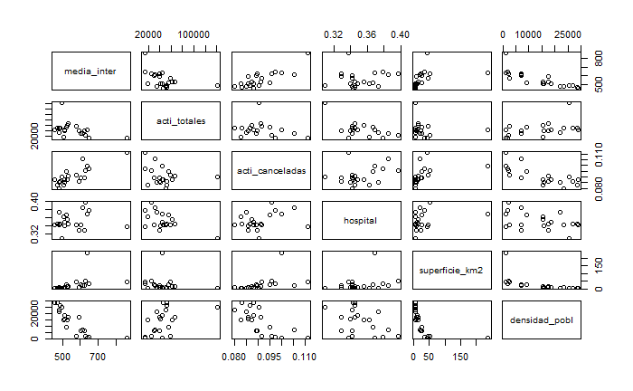

```r
plot(dfPrueba1)
```

### 3.1.1 Preguntas de interés

#### ¿Qué distrito tiene más intervenciones? ¿Y menos?

El distrito con más intervenciones es el distrito Centro, estando muy por encima de cualquier otro distrito. Se puede deber a que es el distrito más turítico. Los distritos que menos intervenciones tiene son Vicálvaro, Moratalaz y Barajas.

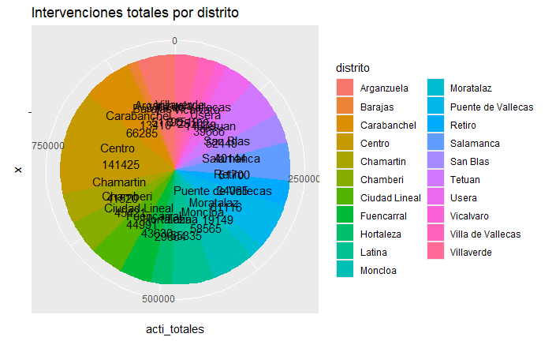

```r
pieChart <- ggplot(dfPrueba1ConNombres, aes(x = "", y = acti_totales, fill = distrito, label = paste(distrito, "\n", acti_totales))) +
  geom_bar(stat = "identity") +
  coord_polar("y", start=0) +
  geom_text(aes(label = paste(distrito, "\n", acti_totales)), position = position_stack(vjust = 0.5)) +
  labs(title = "Intervenciones totales por distrito")
pieChart
```

#### ¿Qué distrito tiene mayor media de tiempo de intervención? ¿Y menos?

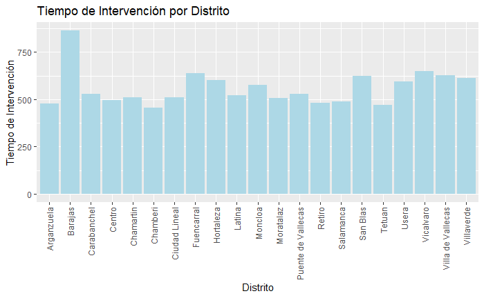

```r
barplot <- ggplot(dfPrueba1ConNombres, aes(x = distrito, y = media_inter)) +
  geom_bar(stat = "identity", fill = "lightblue") +
  labs(title = "Tiempo de Intervención por Distrito", y = "Tiempo de Intervención", x = "Distrito") +
  theme(axis.text.x = element_text(angle = 90, vjust = 0.5, hjust=1))  # Rotamos los nombres del eje x

barplot
```

Barajas parece ser el distrito en el que los recurso tardan más en intervenir. El resto de distritos no parece tener mucha diferencia entre ellos, no hay picos que destaquen.

#### ¿Cual es el distrito con mayor superficie? ¿Y menos? ¿Cual es el distrito con mayor densidad de población? ¿Y menos?

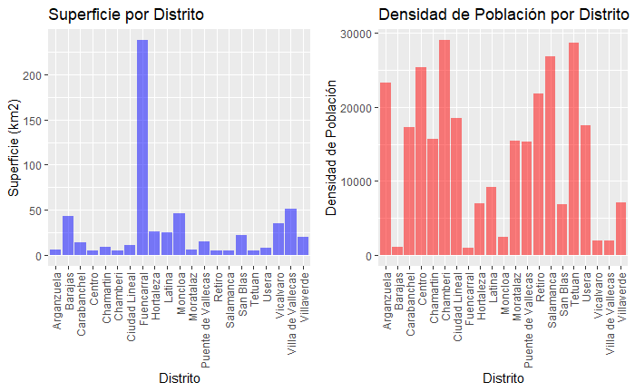

```r
plotArea <- ggplot(dfPrueba1ConNombres, aes(x = distrito, y = superficie_km2)) +
  geom_bar(stat = "identity", fill = "blue", alpha = 0.5) +
  labs(title = "Superficie por Distrito", y = "Superficie (km2)", x = "Distrito") +
  theme(axis.text.x = element_text(angle = 90, vjust = 0.5, hjust=1))  # Rotamos los nombres del eje x


plotDensity <- ggplot(dfPrueba1ConNombres, aes(x = distrito, y = densidad_pobl)) +
  geom_bar(stat = "identity", fill = "red", alpha = 0.5) +
  labs(title = "Densidad de Población por Distrito", y = "Densidad de Población", x = "Distrito") +
  theme(axis.text.x = element_text(angle = 90, vjust = 0.5, hjust=1))  # Rotamos los nombres del eje x


grid.arrange(plotArea, plotDensity, ncol = 2)
```

Podemos observar que el distrito Fuencarral se lleva el premio a distrito más grande, ya que abarca toda la superficie de El Pardo (nombre oficial del distrito: Fuencarral - El Pardo). La densidad de población isn embargo, podríamos decir que es un poco más competitiva. Sigue habiendo muchas diferencias entre distritos, como Barajas y Ciudad Lineal, pero ya no hay un distrito que destaca por encima del resto.

#### ¿Cual es el distrito con mayor ratio de hospitalización? ¿Y menos? ¿Hay mucha diferencia entre el resto de distritos? ¿Y menos?

```r
dfPrueba1ConNombres[order(-dfPrueba1ConNombres$hospital), ]
```

|  | distrito | media_inter | acti_totales | acti_canceladas | hospital | superficie_km2 | densidad_pobl |
| --- | --- | --- | --- | --- | --- | --- | --- |
| 20 | Villa de Vallecas | 626.6384 | 25102 | 0.09580910 | 0.3965722 | 51.49 | 2026.82 |
| 21 | Villaverde | 612.5747 | 31519 | 0.10536502 | 0.3849209 | 20.21 | 7059.13 |
| 19 | Vicalvaro | 649.1620 | 14679 | 0.09700933 | 0.3780460 | 35.36 | 1981.11 |
| 14 | Retiro | 482.8065 | 34065 | 0.08507266 | 0.3727982 | 5.42 | 21867.53 |
| 8 | Fuencarral | 636.3362 | 43630 | 0.09981664 | 0.3692680 | 238.00 | 1003.00 |
| 10 | Latina | 519.5548 | 55335 | 0.09482245 | 0.3665349 | 25.47 | 9183.75 |
| 12 | Moratalaz | 508.4783 | 19149 | 0.08261528 | 0.3621563 | 6.08 | 15493.59 |
| 13 | Puente de Vallecas | 527.2727 | 61116 | 0.08726029 | 0.3556460 | 14.84 | 15345.01 |
| 7 | Ciudad Lineal | 509.7735 | 44991 | 0.08790647 | 0.3479140 | 11.52 | 18455.56 |
| 3 | Carabanchel | 529.8801 | 66285 | 0.09097081 | 0.3448013 | 14.10 | 17316.88 |

[output cut: 11 more lines]

#### ¿Cual es el distrito con mayor ratio de intervenciones canceladas? ¿Y menos? ¿Hay mucha diferencia entre el resto de distritos?

```r
dfPrueba1ConNombres[order(-dfPrueba1ConNombres$acti_canceladas), ]
```

|  | distrito | media_inter | acti_totales | acti_canceladas | hospital | superficie_km2 | densidad_pobl |
| --- | --- | --- | --- | --- | --- | --- | --- |
| 2 | Barajas | 863.8694 | 13410 | 0.11103654 | 0.3373878 | 43.56 | 1076.06 |
| 21 | Villaverde | 612.5747 | 31519 | 0.10536502 | 0.3849209 | 20.21 | 7059.13 |
| 8 | Fuencarral | 636.3362 | 43630 | 0.09981664 | 0.3692680 | 238.00 | 1003.00 |
| 19 | Vicalvaro | 649.1620 | 14679 | 0.09700933 | 0.3780460 | 35.36 | 1981.11 |
| 20 | Villa de Vallecas | 626.6384 | 25102 | 0.09580910 | 0.3965722 | 51.49 | 2026.82 |
| 10 | Latina | 519.5548 | 55335 | 0.09482245 | 0.3665349 | 25.47 | 9183.75 |
| 11 | Moncloa | 576.6782 | 58565 | 0.09135149 | 0.3418961 | 46.47 | 2515.26 |
| 3 | Carabanchel | 529.8801 | 66285 | 0.09097081 | 0.3448013 | 14.10 | 17316.88 |
| 4 | Centro | 494.4389 | 141425 | 0.09021743 | 0.3093125 | 5.21 | 25340.69 |
| 16 | San Blas | 622.4151 | 40144 | 0.08942806 | 0.3282814 | 22.26 | 6934.37 |

[output cut: 11 more lines]

El distrito con mayor ratio de cancelación sería el distrito de Barajas. Como podemos observar, tampoco hay mucha diferencia entre este distrito y el resto de locaclizaciones, al igual que ocurre con la hospitalización.

## 3.2. Análisis de Componentes Principales (PCA)

Análisis de Componentes Principales (de ahora en adelante PCA por sus siglas en inglés) es una técnica de reducción de dimensionalidad. Su objetivo es simplificar conjuntos de datos complejos conservando la mayor cantidad posible de información. PCA coge un conjunto de datos con muchas características y variables y las transforma en un nuevo conjunto de variables llamads componentes principales, ordenados en función de la cantidad de varianza que explican.

En este caso, aplicaré PCA para ver si puedo reducir el número de columnas que nos encontramos a unos pocos componentes guardando la mayor inforamción posible.

Antes de meternos en el proceso de PCA, es importante tener en cuenta que los datos están en escalas altamente diferentes, y esto podría llevar a casos como que una variable con mayor varianza arrastre al resto. Para tratar esto voy a tipificar los datos para asegurarme de que las variables tengan la misma escala y distribución.

```r
dfPrueba1 <- dfPrueba1 %>% mutate(across(where(is.numeric), scale))
dfPrueba1
```

| media_inter | acti_totales | acti_canceladas | hospital | superficie_km2 | densidad_pobl |
| --- | --- | --- | --- | --- | --- |
| -0.8712361 | 0.20520908 | -1.40909007 | -0.4891909 | -0.44402864 | 0.9666179 |
| 3.2747977 | -1.22231316 | 2.65082829 | -0.6727672 | 0.29437996 | -1.3385932 |
| -0.3242145 | 0.77531125 | 0.02700221 | -0.3167240 | -0.29291802 | 0.3455219 |
| -0.7061227 | 3.61411028 | -0.07151068 | -2.0211296 | -0.47014406 | 1.1775624 |
| -0.5172687 | -0.16031369 | -0.67879501 | -0.5457690 | -0.39219650 | 0.1802681 |
| -1.1347245 | -0.01293340 | -0.38175555 | -0.4076756 | -0.47971307 | 1.5621278 |
| -0.5408794 | -0.02917885 | -0.37369532 | -0.1672284 | -0.34435145 | 0.4635989 |
| 0.8229390 | -0.08059761 | 1.18369686 | 0.8583297 | 4.17062637 | -1.3461693 |
| 0.4456498 | -0.60823492 | -0.23112685 | -0.4409656 | -0.05827793 | -0.7270673 |
| -0.4354779 | 0.36161882 | 0.53064824 | 0.7270689 | -0.06625210 | -0.4978547 |

[output cut: 11 more lines]

```r
rownames(dfPrueba1) <- nombresPrueba1
pca1 = prcomp(dfPrueba1, center = TRUE, scale = TRUE)
pca1$rotation
```

```
                       PC1        PC2         PC3         PC4         PC5          PC6
media_inter      0.4699857  0.2927221  0.41106517  0.10691945 -0.10932455  0.707862233
acti_totales    -0.3298201  0.5954624 -0.36466589 -0.48159608  0.28460691  0.301207868
acti_canceladas  0.4600763  0.2940454  0.09102678 -0.55478041 -0.41681793 -0.460502688
hospital         0.3054238 -0.6443087 -0.36574133 -0.47869809  0.04698517  0.355607140
superficie_km2   0.3407608  0.2246122 -0.74536035  0.46364012 -0.25076433  0.004948945
densidad_pobl   -0.4992598 -0.0877000 -0.02072571 -0.06883406 -0.81744694  0.263934126
```

```r
summary(pca1)
```

```
Importance of components:
                          PC1    PC2    PC3     PC4     PC5     PC6
Standard deviation     1.8268 1.0664 0.8934 0.67228 0.47971 0.21230
Proportion of Variance 0.5562 0.1895 0.1330 0.07533 0.03835 0.00751
Cumulative Proportion  0.5562 0.7458 0.8788 0.95414 0.99249 1.00000
```

Como vemos, los tres primeros componentes explican por sí mismos el 87% de la variabilidad.

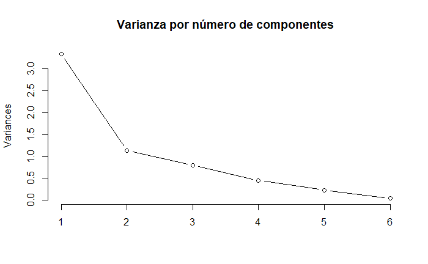

```r
plot(pca1, type = "l", main="Varianza por número de componentes")
```

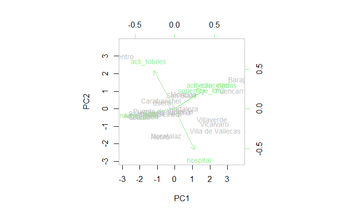

```r
biplot(x = pca1, scale = 0, cex = 0.9, col = c("grey", "lightgreen"))
```

Observaciones del gráfico de PCA: - Los distritos no se concentran en un centro, están un poco dispersos, aunque es cierto que tienden a agruparse unos pocos en el centro de las flejas.

- El distrito Centro es uno de los más alejados. Como ya he comentado antes, es el que más activaciones tiene registradas y puede ser motivo por el que esté tirando en esa dirección.
- El distrito de Barajas es otro de los que están bastantes dispersos. Antes hemos visto que es el distrito que más ratio de cancelación de activaciones tiene y uno de los que menos densidad de población tiene también.
- El distrito Fuencarral está muy a la derecha, tirando fuertemente de la flecha de superficie. Tiene sentido, al ser el distrito con mayor superficie por kilómetro cuadrado.
- Distritos Vicálvaro, Villa de Vallecas y Villaverde están en un grupo juntos abajo a la derecha. Si recordamos, corresponden a los tres primeros con mayor ratio de hospitalización en todo el municipio y tiene sentido que sigan esa tendencia en el gráfico.
- Distritos Moratalaz y Retiro no se quedan atrás en el ratio de hospitalización, pero destacan más, sobre todo por el distrito Retiro, por su densidad de población.

## 3.3 Análisis Cluster

Visto lo visto en PCA, me quedo con los 3 primeros componentes, conteniendo un 87% de la variabilidad de los datos.

```r
pcs1 <- pca1$x[, 1:3]
```

El análisis cluster que voy a aplicar primero será el K-Means. K-Means es un algoritmo de agrupamiento de datos en diferentes clusters. Funciona iterativamente asignando puntos de datos al centroide más cercano y actualizando los centroides para minimizar la suma de las distancias cuadradas dentro de cada cluster. Es sensible a los valores atípicos y la elección de los centroides iniciales, y típicamente utiliza la métrica de distancia euclidiana para el agrupamiento.

La K es un número que representa en cuántos clusters queremos dividir los datos. Para estimar mejor cuántos deberíamos utilizar, voy a aplicar el “Elbow Method”, en donde se realiza el K-means para diferentes valores de K y se grafica la suma de las distancias cuadradas dentro de cada cluster en función de K. En el gráfico resultante, se busca el “codo” o punto de inflexión donde la disminución de la suma de las distancias se vuelve menos pronunciada. Este punto suele indicar el número óptimo de clusters para el conjunto de datos dado.

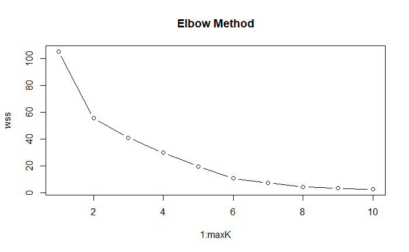

```r
dataK <- pcs1

maxK <- as.integer(10)

wss <- numeric(maxK)

for (k in 1:maxK) {
  set.seed(123)

  kmeans_fit <- kmeans(dataK, centers = k, nstart = 50)

  wss[k] <- kmeans_fit$tot.withinss
}

plot(1:maxK, wss, type = "b", main = "Elbow Method")
```

```r
gapSatistic <- clusGap(pcs1,
                    FUN = pam,
                    K.max = 10,
                    B = 50)
```

```
Clustering k = 1,2,..., K.max (= 10): .. done
Bootstrapping, b = 1,2,..., B (= 50)  [one "." per sample]:
.................................................. 50
```

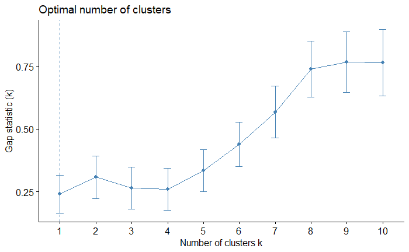

```r
fviz_gap_stat(gapSatistic)
```

```r
kmeansModel <- kmeans(pcs1, centers = 2, nstart = 20)
```

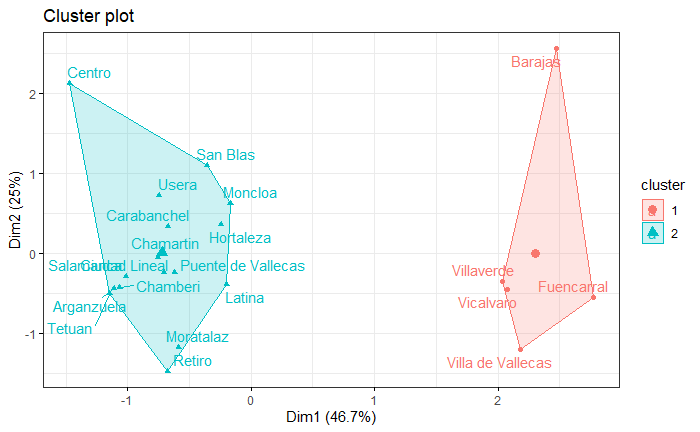

```r
resultCluster <- cbind(cluster = kmeansModel$cluster, pcs1)

fviz_cluster(kmeansModel, data = resultCluster, repel = TRUE, ggtheme = theme_bw())
```

# 4. Prueba 2 - Datos agrupados por código de emergencia

En esta parte voy a exponer un Análisis de Componentes Principales y un Análisis Cluster de los datos agrupados por por código de emergencia. Como recordatorio, en nuestro dataset del SAMUR, a cada una de las activaciones se le asigna un código de emergencia, para clasificarla en función del incidente. Esa columna es la que vamos a utilizar ahora para crear un nuevo dataframe, el cual contendrá las siguientes columnas:

- **codigo**: Código de emergencia
- **media_inter**: Media del tiempo de intervención.
- **acti_totales**: Número de activaciones totales registradas a ese código.
- **acti_canceladas**: Ratio de activaciones canceladas con ese código. En función de las activaciones totales del código.
- **hospital**: Ratio de hospitalización en función de las activaciones realizadas.
- **noche**: Ratio de activaciones realizadas por la noche. Considero noche todas las horas entre las 21:00 y las 9:00

He decidido prescindir de todos los registros que no tienen un código asignado, ya que no dan información relevante para este caso. Adicionalmente, investigando un poco me he dado cuenta de que el código “Pacientes en RCP Prolongada” solo ha ocurrido 1 vez en 7 años, y al parecer la activación fue cancelada ya que no disponemos de hora de intervención. Ya que este registro tampoco aporta información de valor en el análisis, he decidido prescindir de él también.

```r
dfSamurTotal$noche <- ifelse(hour(dfSamurTotal$fecha_solicitud) >= 9 & hour(dfSamurTotal$fecha_solicitud) < 21, 0, 1)

dfSamurPorCodigo <- dfSamurTotal %>% filter(!is.na(codigo)) %>% filter(codigo != "Pacientes en RCP prolongada")

dfSamurPorCodigo <- dfSamurPorCodigo %>%
  group_by(codigo) %>%
  summarize(
    media_inter = mean(tiempo_intervencion, na.rm = TRUE),
    acti_totales = n(),
    acti_canceladas = sum(is.na(tiempo_intervencion)) / n(),
    noche = sum(is.na(noche)) / n(),
    hospital = mean(as.numeric(hospital), na.rm=T)
  )
dfSamurPorCodigo
```

| codigo | media_inter | acti_totales | acti_canceladas | noche | hospital |
| --- | --- | --- | --- | --- | --- |
| + de 3 SVB y eq. Sanit. | 2844.67306 | 1264 | 0.17484177 | 0.029272152 | 0.046021093 |
| 1 SVB | 1961.40327 | 11510 | 0.06498697 | 0.028062554 | 0.016539677 |
| 1 o + SVB y 1 o + SVA | 2642.65142 | 1225 | 0.05387755 | 0.020408163 | 0.033649698 |
| 1 o + SVB y 1 o + SVA y PMA | 2193.68585 | 1963 | 0.13245033 | 0.021905247 | 0.048737522 |
| Acc. Trasp. Merc. Peligrosas | 2311.00000 | 3 | 0.33333333 | 0.000000000 | 0.000000000 |
| Accidente con 3 o más víctimas confirmadas | 523.49195 | 1064 | 0.06578947 | 0.007518797 | 0.449698189 |
| Accidente con vehículo pesado | 638.88119 | 231 | 0.12554113 | 0.012987013 | 0.400990099 |
| Accidente de autobús / autocar | 452.78052 | 727 | 0.05364512 | 0.004126547 | 0.364825581 |
| Accidente de avión | 590.69388 | 58 | 0.15517241 | 0.034482759 | 0.081632653 |
| Accidente de bicicleta | 488.21863 | 8195 | 0.07406955 | 0.007931666 | 0.514232999 |

[output cut: 89 more lines]

```r
nombresPrueba2 <- dfSamurPorCodigo$codigo
dfPrueba2 <- select(dfSamurPorCodigo, -codigo)
dfPrueba2
```

| media_inter | acti_totales | acti_canceladas | noche | hospital |
| --- | --- | --- | --- | --- |
| 2844.67306 | 1264 | 0.17484177 | 0.029272152 | 0.046021093 |
| 1961.40327 | 11510 | 0.06498697 | 0.028062554 | 0.016539677 |
| 2642.65142 | 1225 | 0.05387755 | 0.020408163 | 0.033649698 |
| 2193.68585 | 1963 | 0.13245033 | 0.021905247 | 0.048737522 |
| 2311.00000 | 3 | 0.33333333 | 0.000000000 | 0.000000000 |
| 523.49195 | 1064 | 0.06578947 | 0.007518797 | 0.449698189 |
| 638.88119 | 231 | 0.12554113 | 0.012987013 | 0.400990099 |
| 452.78052 | 727 | 0.05364512 | 0.004126547 | 0.364825581 |
| 590.69388 | 58 | 0.15517241 | 0.034482759 | 0.081632653 |
| 488.21863 | 8195 | 0.07406955 | 0.007931666 | 0.514232999 |

[output cut: 89 more lines]

## 4.1 Análisis de los datos

```r
summary(dfPrueba2)
```

```
  media_inter      acti_totales      acti_canceladas       noche             hospital
 Min.   :   0.0   Min.   :     1.0   Min.   :0.00000   Min.   :0.000000   Min.   :0.00000
 1st Qu.: 477.5   1st Qu.:   174.5   1st Qu.:0.06835   1st Qu.:0.006484   1st Qu.:0.03841
 Median : 544.5   Median :  1064.0   Median :0.09412   Median :0.009816   Median :0.21463
 Mean   : 782.7   Mean   :  9802.0   Mean   :0.12031   Mean   :0.026793   Mean   :0.24729
 3rd Qu.: 771.7   3rd Qu.:  5944.0   3rd Qu.:0.14977   3rd Qu.:0.021692   3rd Qu.:0.41683
 Max.   :3186.2   Max.   :164565.0   Max.   :0.47573   Max.   :0.276699   Max.   :0.94204
```

Al igual que pasaba con el ejemplo anterior, los datos están en escalas muy diferentes, cosa que habrá que tener en cuenta para el PCA y el análisis Cluster.

```r
varianza = apply(X = dfPrueba2, MARGIN = 2, FUN = var)
varianza
```

```
    media_inter    acti_totales acti_canceladas           noche        hospital
   3.904919e+05    6.802949e+08    8.060801e-03    2.670274e-03    5.153097e-02
```

Podemos observar que las varianzas en las tres últimas columnas (activaciones canceladas, noche y hospital) no son nada grandes, al contrario, los datos están bastante igualados.

```r
cor(dfPrueba2)
```

```
                media_inter acti_totales acti_canceladas      noche   hospital
media_inter       1.0000000   -0.1448614       0.3231527  0.3958351 -0.2714262
acti_totales     -0.1448614    1.0000000      -0.1270934 -0.1208304  0.1573512
acti_canceladas   0.3231527   -0.1270934       1.0000000  0.7299684 -0.1345309
noche             0.3958351   -0.1208304       0.7299684  1.0000000 -0.2857489
hospital         -0.2714262    0.1573512      -0.1345309 -0.2857489  1.0000000
```

Aquí podemos observar que no hay datos con mucha covarianza. El único dato que destaca así mucho sería el ratio de activaciones por la noche y las cancelaciones.

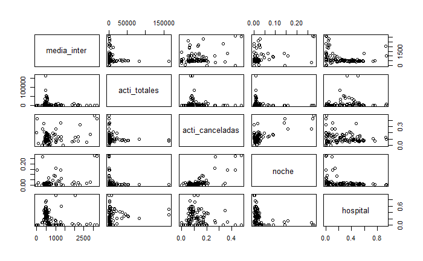

```r
plot(dfPrueba2)
```

### 4.1.1 Preguntas de interés

#### ¿Qué código tiene más activaciones asignadas? ¿Y menos?

```r
dfSamurPorCodigo[order(-dfSamurPorCodigo$acti_totales), ]
```

| codigo | media_inter | acti_totales | acti_canceladas | noche | hospital |
| --- | --- | --- | --- | --- | --- |
| Patología cardiovascular | 462.92008 | 164565 | 0.08496946 | 0.008640963 | 0.332808702 |
| Casual: caída, etc | 455.01799 | 164097 | 0.07092756 | 0.008245123 | 0.504020779 |
| Intoxicación etílica | 459.02140 | 82782 | 0.09906743 | 0.008552584 | 0.214625709 |
| Agresión sin especificar | 500.64199 | 52376 | 0.08255690 | 0.006186039 | 0.274494298 |
| Accidente menos de 3 victimas | 531.38752 | 50295 | 0.08348742 | 0.008390496 | 0.294515793 |
| Heridas | 529.65610 | 44981 | 0.07271959 | 0.008670327 | 0.356485255 |
| Otros | 548.17660 | 41169 | 0.09315261 | 0.011537808 | 0.299217871 |
| Accidente de motocicleta | 439.28823 | 35992 | 0.08529673 | 0.008751945 | 0.407265658 |
| Patología psicosomática | 555.12090 | 34754 | 0.07872475 | 0.008517005 | 0.220657130 |
| Certificación psiquiátrico | 556.73527 | 30038 | 0.09168387 | 0.009221653 | 0.433587451 |

[output cut: 89 more lines]

El código que más se repite a lo largo de los 7 años es “Patología cardiovascular· con un total de casi 165.000 intervenciones totales, seguido de cerca de las intervenciones casuales. En último lugar tenemos los códigos referentes a la atención psicológica a Cuerpos de Seguridad y Bomberos, ocurriendo tan solo 2 y 1 vez respectivamente. Además destaca que ninguna de estas últimas requirió hospitalización y ocurrieron de día.

#### ¿Qué código tiene mayor ratio de cancelaciones? ¿Y menos?

```r
dfSamurPorCodigo[order(-dfSamurPorCodigo$acti_canceladas), ]
```

| codigo | media_inter | acti_totales | acti_canceladas | noche | hospital |
| --- | --- | --- | --- | --- | --- |
| Servicio de formación / divulgación externa. | 3059.74074 | 206 | 0.47572816 | 0.276699029 | 0.009259259 |
| Accidente de tren | 2.75000 | 14 | 0.42857143 | 0.142857143 | 0.000000000 |
| Servicio de logística y otros | 3186.21818 | 96 | 0.42708333 | 0.270833333 | 0.000000000 |
| Accidente sin especificar | 1256.47697 | 477 | 0.36268344 | 0.140461216 | 0.101973684 |
| Ahogado | 384.37857 | 214 | 0.34579439 | 0.018691589 | 0.471428571 |
| Acc. Trasp. Merc. Peligrosas | 2311.00000 | 3 | 0.33333333 | 0.000000000 | 0.000000000 |
| Todos los medios de SAMUR-PC | 304.00000 | 15 | 0.26666667 | 0.266666667 | 0.090909091 |
| Atención psicológica a Implicados. | 1014.21429 | 19 | 0.26315789 | 0.157894737 | 0.142857143 |
| Inconsciente sin filiar causa | 408.29132 | 11448 | 0.21139064 | 0.020877009 | 0.369960124 |
| Electrocutado | 492.87500 | 150 | 0.20000000 | 0.026666667 | 0.383333333 |

[output cut: 89 more lines]

El código con mayor ratio de cancelación, casi un 50% sería el “Servicio de formación / divulgación externa”, seguido de cerca de los accidentes de tren. En último lugar tenemos 6 código que no han tenido ninguna cancelación en los 7 años que expande este dataset y llama la atención que muchos de estos son sobre atención psicológica.

#### ¿Qué código tiene mayor ratio de hospitalizaciones? ¿Y menos?

```r
dfSamurPorCodigo[order(-dfSamurPorCodigo$hospital), ]
```

| codigo | media_inter | acti_totales | acti_canceladas | noche | hospital |
| --- | --- | --- | --- | --- | --- |
| Orden medica | 1022.91469 | 6136 | 0.10022816 | 0.004889179 | 0.942039486 |
| Orden médica urgente /agresivo | 2039.26250 | 92 | 0.13043478 | 0.000000000 | 0.937500000 |
| Autolisis no traumática | 496.52056 | 914 | 0.06892779 | 0.005470460 | 0.761457109 |
| Patología obstétrica | 477.26952 | 1644 | 0.10401460 | 0.010948905 | 0.734555329 |
| Orden judicial | 1311.05144 | 719 | 0.08066759 | 0.009735744 | 0.593040847 |
| Patología ginecológica | 479.85485 | 1481 | 0.07427414 | 0.003376097 | 0.585703866 |
| Infarto o patología coronaria | 464.77169 | 2765 | 0.08282098 | 0.012296564 | 0.580441640 |
| Intoxicación por fármacos y/o productos tóxicos | 496.18084 | 3154 | 0.09004439 | 0.008243500 | 0.577003484 |
| Autolisis traumática | 512.10417 | 1538 | 0.15734720 | 0.016905072 | 0.532407407 |
| Arma blanca | 431.98575 | 3727 | 0.13361953 | 0.015025490 | 0.529575720 |

[output cut: 89 more lines]

“Orden médica” y “Orden médica urgente / agresivo” son los dos códigos con mayor ratio de hospitalización, casi llegando al 95% de las veces. Como contexto, he cogido las definiciones que vienen dadas por el proveedor de los datos: Orden médica: Traslado psiquiátrico forzoso ordenado por un medico Orden médica urgente / agresivo: Orden medica de traslado psiquiátrico urgente por peligrosidad/agresividad extrema del paciente

Como información adicional, hay un total de 15 códigos que nunca han requerido hospitalización en estos 7 años. También es verdad, que no son códigos que generen muchas activaciones, ninguno de ellos pasa de las 100 en total.

#### ¿Qué código suele pasar más por la noche? ¿Y por el día? ¿Hay más sucesos por la noche o por el día?

```r
dfSamurPorCodigo[order(-dfSamurPorCodigo$noche), ]
```

| codigo | media_inter | acti_totales | acti_canceladas | noche | hospital |
| --- | --- | --- | --- | --- | --- |
| Servicio de formación / divulgación externa. | 3059.74074 | 206 | 0.47572816 | 0.276699029 | 0.009259259 |
| Servicio de logística y otros | 3186.21818 | 96 | 0.42708333 | 0.270833333 | 0.000000000 |
| Todos los medios de SAMUR-PC | 304.00000 | 15 | 0.26666667 | 0.266666667 | 0.090909091 |
| Atención psicológica a Implicados. | 1014.21429 | 19 | 0.26315789 | 0.157894737 | 0.142857143 |
| Accidente de tren | 2.75000 | 14 | 0.42857143 | 0.142857143 | 0.000000000 |
| Accidente sin especificar | 1256.47697 | 477 | 0.36268344 | 0.140461216 | 0.101973684 |
| NO APARECE EN CODIGO INICIAL | 917.87458 | 353 | 0.16430595 | 0.090651558 | 0.013559322 |
| Atención psicológica a la Víctima primaria | 993.71642 | 81 | 0.17283951 | 0.086419753 | 0.164179104 |
| Riesgo biológico | 634.08333 | 14 | 0.14285714 | 0.071428571 | 0.000000000 |
| Servicios especiales | 1289.62223 | 2365 | 0.14038055 | 0.064693446 | 0.008362027 |

[output cut: 89 more lines]

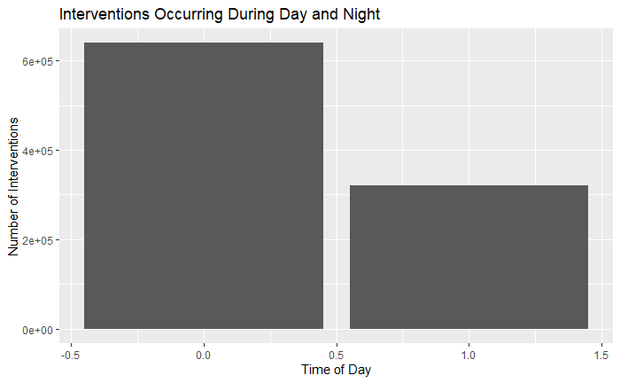

```r
ggplot(dfSamurTotal, aes(x = noche)) +
  geom_bar() +
  labs(x = "Time of Day", y = "Number of Interventions", title = "Interventions Occurring During Day and Night")
```

Como se puede observar, la mayoría de las intervenciones ocurren de día, lo cual si se piensa tiene sentido ya que es cuando más gente hay despierta y más emergencias pueden ocurrir. El código que más ocurre por la noche, pero con tan solo un 27% de las veces sería el de divulgación y formación. Por el otro extremo, tenemos 13 códigos que no han surgido nunca entre las 9pm y 9 am.

#### ¿Qué código tiene mayor media de tiempo de intervención? ¿Y menos?

```r
dfSamurPorCodigo[order(-dfSamurPorCodigo$media_inter), ]
```

| codigo | media_inter | acti_totales | acti_canceladas | noche | hospital |
| --- | --- | --- | --- | --- | --- |
| Servicio de logística y otros | 3186.21818 | 96 | 0.42708333 | 0.270833333 | 0.000000000 |
| Servicio de formación / divulgación externa. | 3059.74074 | 206 | 0.47572816 | 0.276699029 | 0.009259259 |
| + de 3 SVB y eq. Sanit. | 2844.67306 | 1264 | 0.17484177 | 0.029272152 | 0.046021093 |
| 1 o + SVB y 1 o + SVA | 2642.65142 | 1225 | 0.05387755 | 0.020408163 | 0.033649698 |
| Acc. Trasp. Merc. Peligrosas | 2311.00000 | 3 | 0.33333333 | 0.000000000 | 0.000000000 |
| Hasta 3 SVB | 2199.84678 | 2632 | 0.06762918 | 0.026975684 | 0.038712306 |
| 1 o + SVB y 1 o + SVA y PMA | 2193.68585 | 1963 | 0.13245033 | 0.021905247 | 0.048737522 |
| Orden médica urgente /agresivo | 2039.26250 | 92 | 0.13043478 | 0.000000000 | 0.937500000 |
| 1 SVB | 1961.40327 | 11510 | 0.06498697 | 0.028062554 | 0.016539677 |
| Serv. Preventivo desde oper. Ordinario | 1894.65115 | 4288 | 0.06343284 | 0.012593284 | 0.038097610 |

[output cut: 89 more lines]

## 4.2 Análisis de Componentes Principales (PCA)

Una vez más, antes de realizar el análisis cluster voy a aplicar PCA al dataframe. Es importante tener en cuenta una vez más las escalas de los datos.

```r
dfPrueba2ConCodigo <- dfSamurPorCodigo %>% mutate(across(where(is.numeric), scale))
dfPrueba2ConCodigo
```

| codigo | media_inter | acti_totales | acti_canceladas | noche | hospital |
| --- | --- | --- | --- | --- | --- |
| + de 3 SVB y eq. Sanit. | 3.299723616 | -0.32734676 | 0.607414853 | 0.047976990 | -0.886633176 |
| 1 SVB | 1.886251106 | 0.06548422 | -0.616158312 | 0.024569062 | -1.016504769 |
| 1 o + SVB y 1 o + SVA | 2.976433913 | -0.32884201 | -0.739896044 | -0.123557415 | -0.941131669 |
| 1 o + SVB y 1 o + SVA y PMA | 2.257966569 | -0.30054714 | 0.135254987 | -0.094586103 | -0.874666758 |
| Acc. Trasp. Merc. Peligrosas | 2.445701201 | -0.37569341 | 2.372708802 | -0.518492729 | -1.089365384 |
| Accidente con 3 o más víctimas confirmadas | -0.414799095 | -0.33501474 | -0.607219927 | -0.372990245 | 0.891645949 |
| Accidente con vehículo pesado | -0.230144852 | -0.36695191 | 0.058299604 | -0.267170257 | 0.677076976 |
| Accidente de autobús / autocar | -0.527956662 | -0.34793530 | -0.742484917 | -0.438636483 | 0.517764973 |
| Accidente de avión | -0.307257689 | -0.37358472 | 0.388335686 | 0.148811768 | -0.729757063 |
| Accidente de bicicleta | -0.471246020 | -0.06161266 | -0.514995605 | -0.365000481 | 1.175934820 |

[output cut: 89 more lines]

```r
dfPrueba2 <- select(dfPrueba2ConCodigo, -codigo)
rownames(dfPrueba2) <- nombresPrueba2
pca2 = prcomp(dfPrueba2, center = TRUE, scale = TRUE)
pca1$rotation
```

[output not shown]

```r
summary(pca2)
```

```
Importance of components:
                          PC1    PC2    PC3    PC4     PC5
Standard deviation     1.4785 1.0103 0.9265 0.8268 0.50129
Proportion of Variance 0.4372 0.2041 0.1717 0.1367 0.05026
Cumulative Proportion  0.4372 0.6413 0.8130 0.9497 1.00000
```

Como vemos, los tres primeros componentes explican por sí mismos el 81% de la variabilidad.

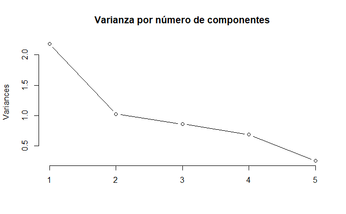

```r
plot(pca2, type = "l", main="Varianza por número de componentes")
```

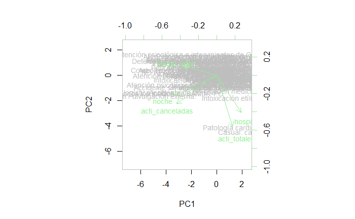

```r
biplot(x = pca2, scale = 0, cex = 0.9, col = c("grey", "lightgreen"))
```

## 4.3 Análisis Cluster

Visto lo visto en PCA, me quedo con los 3 primeros componentes, conteniendo un 81% de la variabilidad de los datos.

```r
pcs2 <- pca2$x[, 1:3]
```

Una vez más voy a aplicar el algoritmo K-Means para realizar el análisis cluster. Para averiguar la K, voy a aplicar de nuevo el “Elbow Method”.

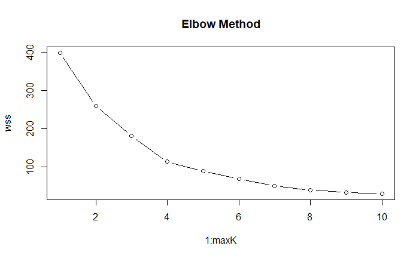

```r
dataK <- pcs2

maxK <- as.integer(10)

wss <- numeric(maxK)

for (k in 1:maxK) {
  set.seed(123)

  kmeans_fit <- kmeans(dataK, centers = k, nstart = 50)

  wss[k] <- kmeans_fit$tot.withinss
}

plot(1:maxK, wss, type = "b", main = "Elbow Method")
```

```r
gapSatistic <- clusGap(pcs2,
                    FUN = pam,
                    K.max = 10,
                    B = 50)
```

```
Clustering k = 1,2,..., K.max (= 10): .. done
Bootstrapping, b = 1,2,..., B (= 50)  [one "." per sample]:
.................................................. 50
```

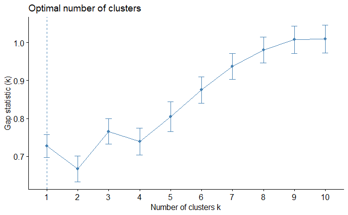

```r
fviz_gap_stat(gapSatistic)
```

```r
kmeansModel <- kmeans(pcs2, centers = 2, nstart = 20)
```

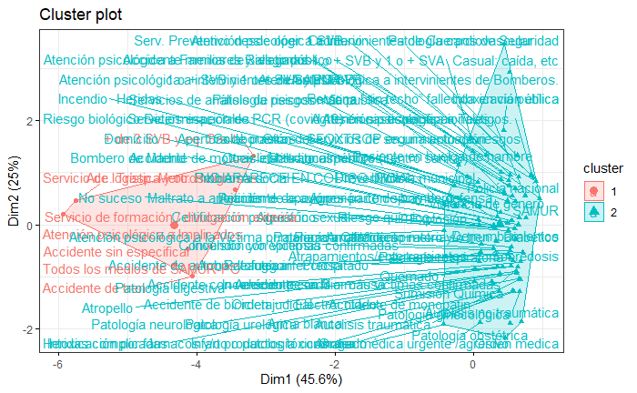

```r
resultCluster <- cbind(cluster = kmeansModel$cluster, pcs2)

fviz_cluster(kmeansModel, data = resultCluster, repel = TRUE, ggtheme = theme_bw())
```

# 5. Referencias y enlaces externos

Datos abiertos del Ayuntamiento de Madrid (2023) Distritos del Municipio de Madrid [en línea] disponible en https://datos.comunidad.madrid/catalogo/dataset/distritos_municipio_madrid [consulta: 06-03-2023]

Datos abiertos del Ayuntamiento de Madrid (2023) Activaciones del SAMUR-Protección civil y Clasificación del incidente (código y descripción) 2022 [en línea] disponible en: https://datos.madrid.es/portal/site/egob/menuitem.c05c1f754a33a9fbe4b2e4b284f1a5a0/?vgnextoid=50d7d35982d6f510VgnVCM1000001d4a900aRCRD&vgnextchannel=374512b9ace9f310VgnVCM100000171f5a0aRCRD&vgnextfmt=default [consulta: 06-03-2024]